# Benchmarking the Leiden Algorithm

[output not shown]

[output not shown]

[output not shown]

[output not shown]

[output not shown]

[output not shown]

[output not shown]

[output not shown]

[output not shown]

[output not shown]

[output not shown]

[output not shown]

[output not shown]

[output not shown]

[output not shown]

[output not shown]

[output not shown]

[output not shown]

[output not shown]

[output not shown]

[output not shown]

[output not shown]

[output not shown]

[output not shown]

[output not shown]

[output not shown]

[output not shown]

```r
end <- Sys.time()
table(partition)
```

```
#> partition
#>  1  2  3  4
#> 11  5 12  6
```

```r
R_sparse_mat_time = difftime(end, start)[[1]]
print(paste(c("leiden time:", R_mat_time, "seconds"), collapse = " "))
```

```
#> [1] "leiden time: 0.916937828063965 seconds"
```

#### Large adjacency matrices

The difference between sparse and dense matrices is more pronounced for large matrices (with few edges):

```r
adjacency_matrix <- rbind(cbind(matrix(round(rbinom(1000000, 1, 0.008)), 1000, 1000),
                                matrix(round(rbinom(1000000, 1, 0.003)), 1000, 1000),
                                matrix(round(rbinom(1000000, 1, 0.001)), 1000, 1000)),
                          cbind(matrix(round(rbinom(1000000, 1, 0.003)), 1000, 1000),
                                matrix(round(rbinom(1000000, 1, 0.008)), 1000, 1000),
                                matrix(round(rbinom(0000000, 1, 0.002)), 1000, 1000)),
                          cbind(matrix(round(rbinom(1000000, 1, 0.003)), 1000, 1000),
                                matrix(round(rbinom(1000000, 1, 0.001)), 1000, 1000),
                                matrix(round(rbinom(1000000, 1, 0.009)), 1000, 1000)))
rownames(adjacency_matrix) <- 1:3000
colnames(adjacency_matrix) <- 1:3000
G <- graph_from_adjacency_matrix(adjacency_matrix)

start <- Sys.time()
for(ii in 1:10){
  adj_mat <- as_adjacency_matrix(G, sparse = FALSE)
}
end <- Sys.time()
class(adj_mat)
```

```
#> [1] "matrix" "array"
```

```r
dim(adj_mat)
```

```
#> [1] 3000 3000
```

```r
R_mat_large_cast_time = difftime(end, start)[[1]]
paste(print(c("cast time:", R_mat_large_cast_time, "seconds"), collapse = " "))
```

```
#> [1] "cast time:"        "0.681180000305176" "seconds"
#> [1] "cast time:"        "0.681180000305176" "seconds"
```

```r
start <- Sys.time()
for(ii in 1:10){
  partition <- leiden(adj_mat, "ModularityVertexPartition")
}
end <- Sys.time()
table(partition)
```

```
#> partition
#>    1    2    3
#> 1023 1002  975
```

```r
R_mat_large_time = difftime(end, start)[[1]]
print(paste(c("leiden time:", R_mat_large_time, "seconds"), collapse = " "))
```

```
#> [1] "leiden time: 25.4750149250031 seconds"
```

For example, on a sparse adjacency matrix:

```r
start <- Sys.time()
for(ii in 1:100){
  adj_mat <- as_adjacency_matrix(G, sparse = TRUE)
}
end <- Sys.time()
class(adj_mat)
```

```
#> [1] "dgCMatrix"
#> attr(,"package")
#> [1] "Matrix"
```

```r
dim(adj_mat)
```

```
#> [1] 3000 3000
```

```r
R_mat_large_cast_time = difftime(end, start)[[1]]
paste(print(c("cast time:", R_mat_large_cast_time, "seconds"), collapse = " "))
```

```
#> [1] "cast time:"        "0.669877052307129" "seconds"
#> [1] "cast time:"        "0.669877052307129" "seconds"
```

```r
start <- Sys.time()
for(ii in 1:10){
  partition <- leiden(adj_mat, "ModularityVertexPartition")
}






























end <- Sys.time()
table(partition)
```

```
#> partition
#>    1    2    3    4
#> 1021 1002  975    2
```

```r
R_mat_large_time = difftime(end, start)[[1]]
print(paste(c("leiden time:", R_mat_large_time, "seconds"), collapse = " "))
```

```
#> [1] "leiden time: 2.1044669508934 seconds"
```

### Comparing the adjacency matrix calling

We compare the processing of adjaceny matrices in the leiden.matrix method to casting to graph in python with reticulate. The current implementation of the R function works as follows. The adjacency matrix is passed to python and the graph object is create in the python-igraph:

```r
partition_type <- "RBConfigurationVertexPartition"
initial_membership <- NULL
weights <- NULL
node_sizes = NULL
resolution_parameter = 1

G <- graph.famous('Zachary')
summary(G)
```

```
#> IGRAPH 993931d U--- 34 78 -- Zachary
#> + attr: name (g/c)
```

```r
time1 <- Sys.time()
object <- as.matrix(as_adjacency_matrix(G))
time2 <- Sys.time()
timing = difftime(time2, time1)[[1]]
print(paste(c("cast to adjacent:", timing, "seconds"), collapse = " "))
```

```
#> [1] "cast to adjacent: 0.00460290908813477 seconds"
```

```r
#run matrix method
leidenalg <- import("leidenalg", delay_load = TRUE)
ig <- import("igraph", delay_load = TRUE)

#convert matrix input (corrects for sparse matrix input)
if(is.matrix(object) || is(adj_mat_sparse, "Matrix")){
  adj_mat <- object
} else{
  adj_mat <- as.matrix(object)
}

#compute weights if non-binary adjacency matrix given
is_pure_adj <- all(as.logical(adj_mat) == adj_mat)
if (is.null(weights) && !is_pure_adj) {
  #assign weights to edges (without dependancy on igraph)
  t_mat <- t(adj_mat)
  weights <- t_mat[t_mat!=0]
  #remove zeroes from rows of matrix and return vector of length edges
}

time3 <- Sys.time()
##convert to python numpy.ndarray, then a list
adj_mat_py <- r_to_py(adj_mat)
adj_mat_py <- adj_mat_py$tolist()
time4 <- Sys.time()
timing = difftime(time4, time3)[[1]]
print(paste(c("pass to python matrix:", timing, "seconds"), collapse = " "))
```

```
#> [1] "pass to python matrix: 0.00513386726379395 seconds"
```

```r
#convert graph structure to a Python compatible object
GraphClass <- if (!is.null(weights) && !is_pure_adj){
  ig$Graph$Weighted_Adjacency
} else {
  ig$Graph$Adjacency
}
time5 <- Sys.time()
snn_graph <- GraphClass(adj_mat_py)
time6 <- Sys.time()
timing = difftime(time6, time5)[[1]]
reticulate_create_time = difftime(time6, time5)[[1]]
print(paste(c("generate graph in python:", timing, "seconds"), collapse = " "))
```

```
#> [1] "generate graph in python: 0.00225305557250977 seconds"
```

```r
# test performance for computing matrix to graph in R
# other option is to passing snn_graph to Python

time7 <- Sys.time()
#compute partitions
source("../R/find_partition.R")

partition <- find_partition(snn_graph, partition_type = partition_type,
                            initial_membership = initial_membership ,
                            weights = weights,
                            node_sizes = node_sizes,
                            resolution_parameter = resolution_parameter
)
time8 <- Sys.time()
timing = difftime(time8, time7)[[1]]
print(paste(c("compute partitions:", timing, "seconds"), collapse = " "))
```

```
#> [1] "compute partitions: 0.0721719264984131 seconds"
```

```r
timing = difftime(time8, time1)[[1]]
print(paste(c("total:", timing, "seconds"), collapse = " "))
```

```
#> [1] "total: 0.10175085067749 seconds"
```

```r
partition
```

```
#>  [1] 1 1 1 1 4 4 4 1 2 1 4 1 1 1 2 2 4 1 2 1 2 1 2 3 3 3 2 3 3 2 2 3 2 2
```

Is it more efficent to pass to create a graph object in R and pass this to python?

```r
partition_type <- "RBConfigurationVertexPartition"
initial_membership <- NULL
weights <- NULL
node_sizes = NULL
resolution_parameter = 1

G <- graph.famous('Zachary')
summary(G)
```

```
#> IGRAPH dfaf242 U--- 34 78 -- Zachary
#> + attr: name (g/c)
```

```r
time1 <- Sys.time()
object <- as.matrix(as_adjacency_matrix(G))
time2 <- Sys.time()
timing = difftime(time2, time1)[[1]]
print(paste(c("cast to adjacent:", timing, "seconds"), collapse = " "))
```

```
#> [1] "cast to adjacent: 0.00580501556396484 seconds"
```

```r
#run matrix method
leidenalg <- import("leidenalg", delay_load = TRUE)
ig <- import("igraph", delay_load = TRUE)

time3 <- Sys.time()
##convert to python numpy.ndarray, then a list
object <- graph_from_adjacency_matrix(adj_mat)
time4 <- Sys.time()
timing = difftime(time4, time3)[[1]]
print(paste(c("generate graph in R:", timing, "seconds"), collapse = " "))
```

```
#> [1] "generate graph in R: 0.00287079811096191 seconds"
```

```r
#convert graph structure to a Python compatible object
time5 <- Sys.time()
##convert to list for python input
    if(!is.named(object)){
        vertices <- as.list(as.character(V(object)))
    } else {
        vertices <- as.list(names(V(object)))
    }

    edges <- as_edgelist(object)
    dim(edges)
```

```
#> [1] 156   2
```

```r
    edgelist <- list(rep(NA, nrow(edges)))
    for(ii in 1:nrow(edges)){
        edgelist[[ii]] <- as.character(edges[ii,])
    }

    snn_graph <- ig$Graph()
    snn_graph$add_vertices(r_to_py(vertices))
    snn_graph$add_edges(r_to_py(edgelist))
time6 <- Sys.time()
timing = difftime(time6, time5)[[1]]
print(paste(c("pass to python graph:", timing, "seconds"), collapse = " "))
```

```
#> [1] "pass to python graph: 0.0658209323883057 seconds"
```

```r
# test performance for computing matrix to graph in R
# other option is to passing snn_graph to Python

time7 <- Sys.time()
#compute partitions
partition <- find_partition(snn_graph, partition_type = partition_type,
                            initial_membership = initial_membership ,
                            weights = weights,
                            node_sizes = node_sizes,
                            resolution_parameter = resolution_parameter
)
time8 <- Sys.time()
timing = difftime(time8, time7)[[1]]
print(paste(c("compute partitions:", timing, "seconds"), collapse = " "))
```

```
#> [1] "compute partitions: 0.0343570709228516 seconds"
```

```r
timing = difftime(time8, time1)[[1]]
print(paste(c("total:", timing, "seconds"), collapse = " "))
```

```
#> [1] "total: 0.127082109451294 seconds"
```

```r
partition
```

```
#>  [1] 1 1 1 1 4 4 4 1 2 1 4 1 1 1 2 2 4 1 2 1 2 1 2 3 3 3 2 3 3 2 2 3 2 2
```

Another approach is to generate a graph in R and pass it to the leiden.igraph method.

```r
partition_type <- "RBConfigurationVertexPartition"
initial_membership <- NULL
weights <- NULL
node_sizes = NULL
resolution_parameter = 1

G <- graph.famous('Zachary')
summary(G)
```

```
#> IGRAPH 58fd8f8 U--- 34 78 -- Zachary
#> + attr: name (g/c)
```

```r
time1 <- Sys.time()
object <- as.matrix(as_adjacency_matrix(G))
time2 <- Sys.time()
timing = difftime(time2, time1)[[1]]
print(paste(c("cast to adjacent:", timing, "seconds"), collapse = " "))
```

```
#> [1] "cast to adjacent: 0.00497102737426758 seconds"
```

```r
time3 <- Sys.time()
##convert to python numpy.ndarray, then a list
object <- graph_from_adjacency_matrix(adj_mat)
time4 <- Sys.time()
timing = difftime(time4, time3)[[1]]
R_graph_create_time = difftime(time4, time3)[[1]]
print(paste(c("generate graph in R:", timing, "seconds"), collapse = " "))
```

```
#> [1] "generate graph in R: 0.00275611877441406 seconds"
```

```r
#convert graph structure to a Python compatible object
time5 <- Sys.time()
##convert to list for python input
   snn_graph <- object
time6 <- Sys.time()
timing = difftime(time6, time5)[[1]]
print(paste(c("pass to R graph:", timing, "seconds"), collapse = " "))
```

```
#> [1] "pass to R graph: 0.0017540454864502 seconds"
```

```r
# test performance for computing matrix to graph in R
# other option is to passing snn_graph to Python

time7 <- Sys.time()
#compute partitions
partition <- leiden(snn_graph, partition_type = partition_type,
                            initial_membership = initial_membership ,
                            weights = weights,
                            node_sizes = node_sizes,
                            resolution_parameter = resolution_parameter
)
```

[output not shown]

```r
time8 <- Sys.time()
timing = difftime(time8, time7)[[1]]
print(paste(c("compute partitions:", timing, "seconds"), collapse = " "))
```

```
#> [1] "compute partitions: 0.0686149597167969 seconds"
```

```r
timing = difftime(time8, time1)[[1]]
print(paste(c("total:", timing, "seconds"), collapse = " "))
```

```
#> [1] "total: 0.0896279811859131 seconds"
```

```r
partition
```

```
#>  [1] 1 1 1 1 4 4 4 1 2 1 4 1 1 1 2 2 4 1 2 1 2 1 2 3 3 3 2 3 3 2 2 3 2 2
```

#### Calling C in R with igraph

Here we compare calling modularity clustering in igraph (R and C) to calling Python via reticulate. Note this is only available for undirected graphs with modularity or CPM. Calling igraph in R does not have a python dependency.

```r
time9 <- Sys.time()
partition <- membership(cluster_leiden(G, objective_function = "modularity"))
partition
```

```
#>  [1] 1 1 1 1 2 2 2 1 3 3 2 1 1 1 3 3 2 1 3 1 3 1 3 4 4 4 3 4 4 3 3 4 3 3
```

```r
table(partition)
```

```
#> partition
#>  1  2  3  4
#> 11  5 12  6
```

```r
time10 <- Sys.time()
timing = difftime(time10, time9)[[1]]
print(paste(c("run with igraph:", timing, "seconds"), collapse = " "))
```

```
#> [1] "run with igraph: 0.0066981315612793 seconds"
```

The updated leiden package calls this implementation when available. We can see this is considerably faster and may be faster than call leidenalg in Python.

```r
time11 <- Sys.time()
partition <- leiden(G, "ModularityVertexPartition", legacy = FALSE)



partition
```

```
#>  [1] 1 2 2 2 1 1 1 2 3 2 1 1 2 2 3 3 1 1 3 1 3 2 3 4 4 4 3 4 4 3 3 4 3 3
```

```r
table(partition)
```

```
#> partition
#>  1  2  3  4
#>  9  8 11  6
```

```r
time12 <- Sys.time()
timing = difftime(time12, time11)[[1]]
print(paste(c("run with leiden in igraph:", timing, "seconds"), collapse = " "))
```

```
#> [1] "run with leiden in igraph: 0.00850510597229004 seconds"
```

This is considerably faster than the reticulate implementation, especially for larger matrices.

```r
time13 <- Sys.time()
partition <- leiden(G, "ModularityVertexPartition", legacy = TRUE)













































































partition
```

```
#>  [1] 2 2 2 2 4 4 4 2 1 1 4 2 2 2 1 1 4 2 1 2 1 2 1 3 3 3 1 3 3 1 1 3 1 1
```

```r
table(partition)
```

```
#> partition
#>  1  2  3  4
#> 12 11  6  5
```

```r
time14 <- Sys.time()
timing = difftime(time14, time13)[[1]]
print(paste(c("run with leiden with reticulate:", timing, "seconds"), collapse = " "))
```

```
#> [1] "run with leiden with reticulate: 0.0500369071960449 seconds"
```

Matrix methods in R are significantly slower than the updated igraph version.

```r
library("Matrix")
adj_mat <- as(as(as(as_adjacency_matrix(G), Class = "CsparseMatrix"), "generalMatrix"), "dMatrix")
time15 <- Sys.time()
partition <- leiden(adj_mat, "ModularityVertexPartition", legacy = TRUE)


```

[output not shown]

```r
partition
```

```
#>  [1] 2 2 2 2 4 4 4 2 1 1 4 2 2 2 1 1 4 2 1 2 1 2 1 3 3 3 1 3 3 1 1 3 1 1
```

```r
table(partition)
```

```
#> partition
#>  1  2  3  4
#> 12 11  6  5
```

```r
time16 <- Sys.time()
timing = difftime(time16, time15)[[1]]
print(paste(c("run with leiden with reticulate:", timing, "seconds"), collapse = " "))
```

```
#> [1] "run with leiden with reticulate: 0.105348825454712 seconds"
```

```r
adj_mat <- as_adjacency_matrix(G)
time15 <- Sys.time()
partition <- leiden(adj_mat, "ModularityVertexPartition", legacy = TRUE)


```

[output not shown]

```r
partition
```

```
#>  [1] 2 2 2 2 4 4 4 2 1 1 4 2 2 2 1 1 4 2 1 2 1 2 1 3 3 3 1 3 3 1 1 3 1 1
```

```r
table(partition)
```

```
#> partition
#>  1  2  3  4
#> 12 11  6  5
```

```r
time16 <- Sys.time()
timing = difftime(time16, time15)[[1]]
print(paste(c("run with leiden with reticulate:", timing, "seconds"), collapse = " "))
```

```
#> [1] "run with leiden with reticulate: 0.0782310962677002 seconds"
```

#### Benchmarking C in R with igraph

For comparison with other methods we compute multiple iterations.

```r
G <- graph.famous('Zachary')
summary(G)
```

```
#> IGRAPH 47ad7b4 U--- 34 78 -- Zachary
#> + attr: name (g/c)
```

```r
start <- Sys.time()
for(ii in 1:100){
  partition <- membership(cluster_leiden(G, objective_function = "modularity"))
}
end <- Sys.time()
table(partition)
```

```
#> partition
#>  1  2  3  4
#> 11  5 12  6
```

```r
igraph_time = difftime(end, start)[[1]]
print(paste(c("leiden time:", igraph_time, "seconds"), collapse = " "))
```

```
#> [1] "leiden time: 0.0761020183563232 seconds"
```

```r
G <- graph.famous('Zachary')
summary(G)
```

```
#> IGRAPH 2ca3c32 U--- 34 78 -- Zachary
#> + attr: name (g/c)
```

```r
start <- Sys.time()
for(ii in 1:100){
  partition <- leiden(G, "ModularityVertexPartition", legacy =  FALSE)
}












































































































































































































































































































end <- Sys.time()
table(partition)
```

```
#> partition
#>  1  2  3  4
#> 11  5 12  6
```

```r
R_cigraph_time = difftime(end, start)[[1]]
print(paste(c("leiden time:", R_cigraph_time, "seconds"), collapse = " "))
```

```
#> [1] "leiden time: 0.180825233459473 seconds"
```

## Summary

Here we compare the compute time for the Zachary datasets between each method for computing paritions from the leiden clustering algorithm in R or Python.

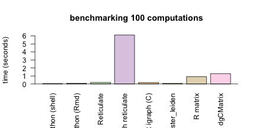

```r
barplot(c(bash_py_time, py$py_time, reticulate_time, R_graph_time,
          R_cigraph_time, igraph_time, R_mat_time, R_sparse_mat_time),
        names = c("Python (shell)", "Python (Rmd)", "Reticulate",
                  "R igraph reticulate", "R igraph (C)", "R igraph cluster_leiden",
                  "R matrix","R dgCMatrix"),
        col = brewer.pal(9,"Pastel1"), las = 2, srt = 45,
        ylab = "time (seconds)", main = "benchmarking 100 computations")
abline(h=0)
```

If we account for time to cast matrices from graph objects. Then these are the time taken to compute partitions from a graph in R.

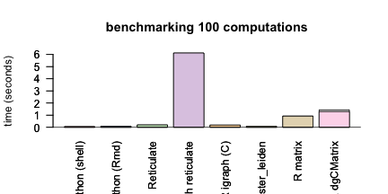

```r
barplot(c(bash_py_time, py$py_time, reticulate_time, R_graph_time,
          R_cigraph_time, igraph_time, R_mat_time+R_mat_cast_time,
          R_sparse_mat_time+R_sparse_mat_cast_time),
        names = c("Python (shell)", "Python (Rmd)", "Reticulate",
                  "R igraph reticulate", "R igraph (C)", "R igraph cluster_leiden",
                  "R matrix","R dgCMatrix"),
        col = "grey80", las = 2, srt = 45,
        ylab = "time (seconds)", main = "benchmarking 100 computations")
barplot(c(bash_py_time, py$py_time, reticulate_time, R_graph_time,
          R_cigraph_time, igraph_time, R_mat_time,  R_sparse_mat_time),
        names = c("Python (shell)", "Python (Rmd)", "Reticulate",
                  "R igraph reticulate", "R igraph (C)", "R igraph cluster_leiden",
                  "R matrix","R dgCMatrix"),
        col = brewer.pal(9,"Pastel1"), las = 2, srt = 45,
        ylab = "time (seconds)", main = "benchmarking 100 computations", add = TRUE)
abline(h=0)
```

Similarly, if we account for time to generate graph from an adjaceny matrix. Then these are the time taken to compute partitions from a matrix in R.

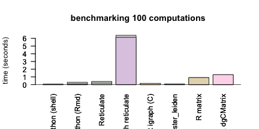

```r
R_graph_create_time = difftime(time4, time3)[[1]]
barplot(c(bash_py_time, py$py_time+reticulate_create_time*100, reticulate_time+reticulate_create_time*100, R_graph_time+R_graph_create_time*100,
        R_cigraph_time, igraph_time, R_mat_time, R_sparse_mat_time),
        names = c("Python (shell)", "Python (Rmd)", "Reticulate",
                  "R igraph reticulate", "R igraph (C)", "R igraph cluster_leiden",
                  "R matrix","R dgCMatrix"),
        col = "grey80", las = 2, srt = 45,
        ylab = "time (seconds)", main = "benchmarking 100 computations")
barplot(c(bash_py_time, py$py_time, reticulate_time, R_graph_time,
        R_cigraph_time, igraph_time, R_mat_time,  R_sparse_mat_time),
        names = c("Python (shell)", "Python (Rmd)", "Reticulate",
                  "R igraph reticulate", "R igraph (C)", "R igraph cluster_leiden",
                  "R matrix","R dgCMatrix"),
        col = brewer.pal(9,"Pastel1"), las = 2, srt = 45,
        ylab = "time (seconds)", main = "benchmarking 100 computations", add = TRUE)
abline(h=0)
```